# Homework 9

Week 9 Assignment: Network Statistics.

Yifan Li (Department of Sociology, UMass Amherst)  
2022-04-06

# Descriptive Statistics

```
[1] FALSE
```

```
[1] TRUE
```

```
[1] TRUE
```

The original dataset is the trade dataset version 4 from the Correlates of War Project. In this subject I only use trade data of year 2014. The format is edgelist. The nodes are countries, and the ties are the trading relations between countries in 2014. The network is directed and weighted.

Let’s look at some basic descriptive facts.

```
[1] 186
```

```
[1] 22451
```

```
[1] 241.4086
```

```
[1] 0.6524557
```

```
    Min.  1st Qu.   Median     Mean  3rd Qu.     Max.
     0.0      0.2      4.9    813.1     78.5 472525.2
```

The network in 2014 has 186 nodes, i.e. 186 countries involed in the trading network. There are 22451 egdes. Each country has 241 connected edges on average. On average, one country import 813 million dollars of good from another country each year. 65% of potential ties exit.

Let’s classify all dyads and traids in the network:

```
$mut
[1] 9933

$asym
[1] 2585

$null
[1] 4687
```

```
 [1]  75574  62420  92513  11021   9514  11233  60137  45246   5530
[10]    788 188669  14094   9006  15882 147383 306230
```

```
[1] 0.07161783
```

```
[1] 0.3484117
```

```
[1] 1
```

There are 9933 mutual bilateral trade relations, 2585 unilateral trade relations, and 4687 pairs of coutries have no trading in 2014.

# Centrality Scores

Let’s look at the distribution of nodes centrality.

The betweenness centrality and reflected centrality are right-skewed as expected. Limited coutries locate at the central bridging positions. But the bonachic-power and closeness show nearly normal distribution, and the eigenvector centrality and deprived centrality are highly left-skewed, which might show a decentralized network. The deprived centrality contribute to largest part of eigenvector centrality. Every country kind of plays as bridge in the network.

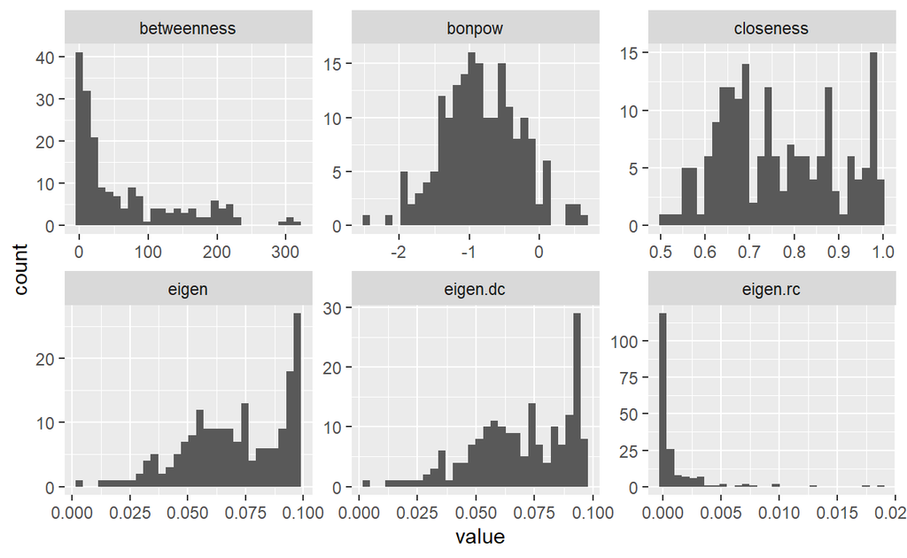

```
 Network attributes:
  vertices = 186
  directed = TRUE
  hyper = FALSE
  loops = FALSE
  multiple = FALSE
  bipartite = FALSE
  total edges= 22451
    missing edges= 0
    non-missing edges= 22451

 Vertex attribute names:
    vertex.names

 Edge attribute names not shown
```

# Using CUG-tests to test network properties

After learning statistics about the network, let’s test whether these statistics are significantly different from null hypothesis. Compare to null network conditioning on size is almost meaningless. The world market is too closely connected and dense. Let’s test against null hypothesis conditioning on density.

```
Univariate Conditional Uniform Graph Test

Conditioning Method: edges
Graph Type: digraph
Diagonal Used: FALSE
Replications: 100

Observed Value: 0.7765289
Pr(X>=Obs): 0
Pr(X<=Obs): 1
```

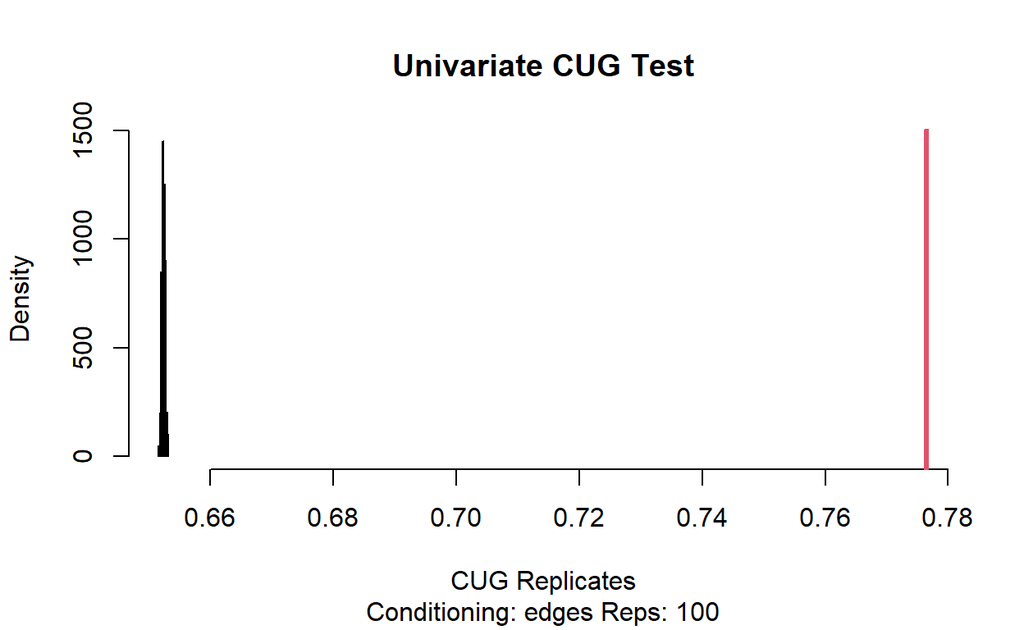

```
[1] 490.4112
```

The observed network transitivity is 0.78. We can feel confident accepting the alternative hypothesis that the observed transitivity is clearly higher than would be expected from a random network.(p<0.001)

```
Univariate Conditional Uniform Graph Test

Conditioning Method: edges
Graph Type: digraph
Diagonal Used: FALSE
Replications: 100

Observed Value: 11702.88
Pr(X>=Obs): 0
Pr(X<=Obs): 1
```

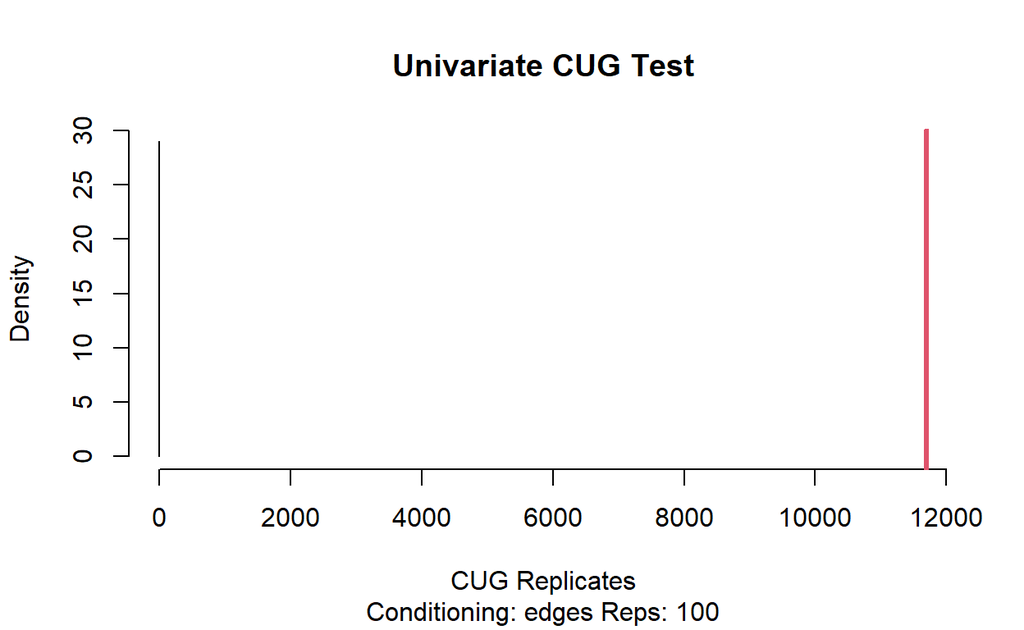

```
[1] 887366.5
```

The observed network degree centralization is 11702.88. We can feel confident accepting the alternative hypothesis that the observed 11702.88 is clearly higher than would be expected from a random network.(p<0.001)

```
Univariate Conditional Uniform Graph Test

Conditioning Method: edges
Graph Type: digraph
Diagonal Used: FALSE
Replications: 50

Observed Value: 0.007458064
Pr(X>=Obs): 0
Pr(X<=Obs): 1
```

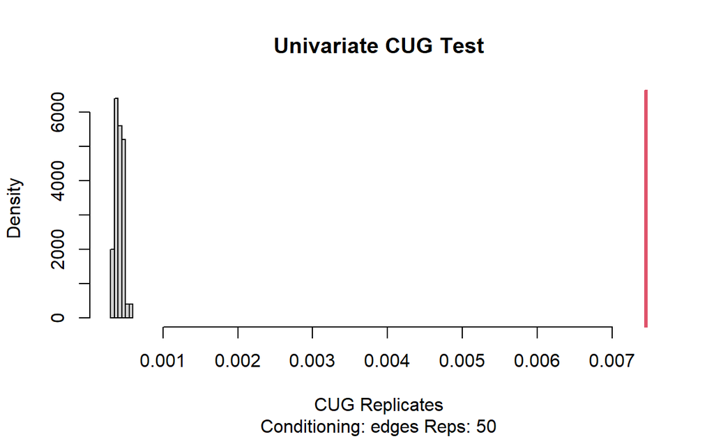

```
[1] 129.5252
```

The observed network betweenness centralization is 0.0075. We can feel confident accepting the alternative hypothesis that the observed betweenness centralization is clearly higher than would be expected from a random network.(p<0.001)

# Compare to Simulated Networks

```
                Observed   Simulated         SD   tvalue
density      0.652455681 0.005376344 0.00000000      Inf
transitivity 0.776528929 0.000000000 0.00000000      Inf
indegCent    0.343988313 0.142198977 0.05181549 3.894382
betwCent     0.007458064 0.002974834 0.00167135 2.682401
```

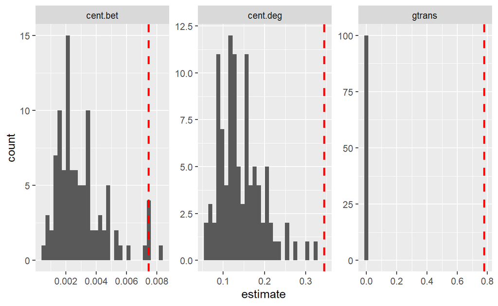

Since the density is very high, let’s model a preferential attachment network with higher average degree.

```
                Observed Simulated SD tvalue
density      0.652455681 0.5000000  0    Inf
transitivity 0.776528929 1.0000000  0   -Inf
indegCent    0.343988313 0.5027027  0   -Inf
betwCent     0.007458064 0.0000000  0    Inf
```

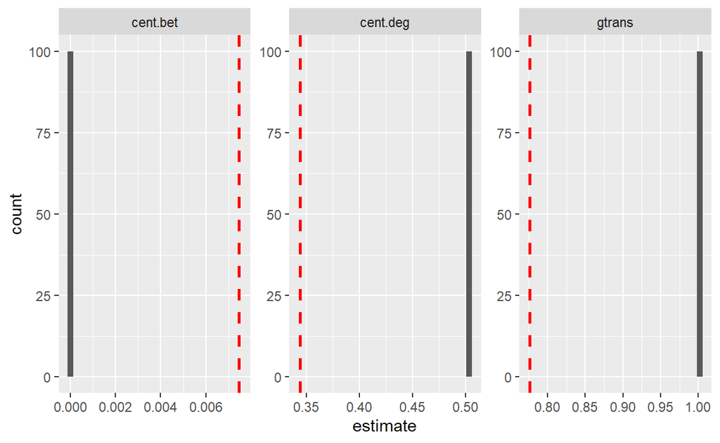

Based on PA model, the observed density and betweeness centrality are still significantly high compared with simulation, while transivity and indegree centrality are lower.(p<0.001)

Notice that the mean of simulated transitivity score is 1.0, indicating a fully transitive network. I think it’s not a good null hypothesis.

Then, simulate a preferential attachment network conditional on the degree distribution we observe, using the out.seq= option。

```
                Observed   Simulated           SD     tvalue
density      0.652455681 0.477390294 0.0000000000        Inf
transitivity 0.776528929 0.990193508 0.0005187225 -411.90536
indegCent    0.343988313 0.513152374 0.0051016389  -33.15877
betwCent     0.007458064 0.001389953 0.0005487202   11.05866
```

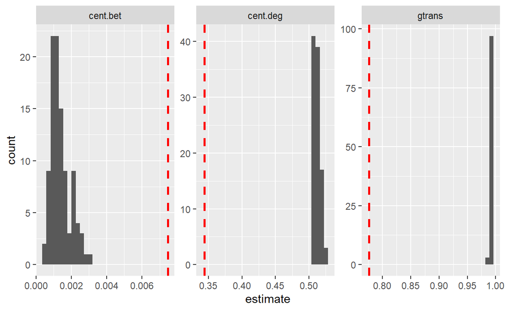

Similarly, the observed density and betweeness centrality are still significantly high compared with simulation, while transivity and indegree centrality are lower. The mean of simulated transitivity score is also near 1.

# Compare with other network.

```
[1] 0.9442986
```

```
QAP Test Results

Estimated p-values:
    p(f(perm) >= f(d)): 0
    p(f(perm) <= f(d)): 1
```

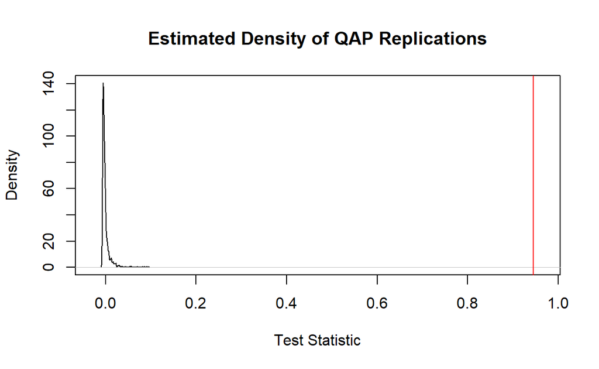

The world trade network in 2004 is very similar with trade2014, with a correlation of 0.94. It’s significantly higher than correlation between two random networks.(p>0.001) During the ten years, the trade partnership didn’t change much.

```
[1] 0.5554877
```

```
QAP Test Results

Estimated p-values:
    p(f(perm) >= f(d)): 0
    p(f(perm) <= f(d)): 1
```

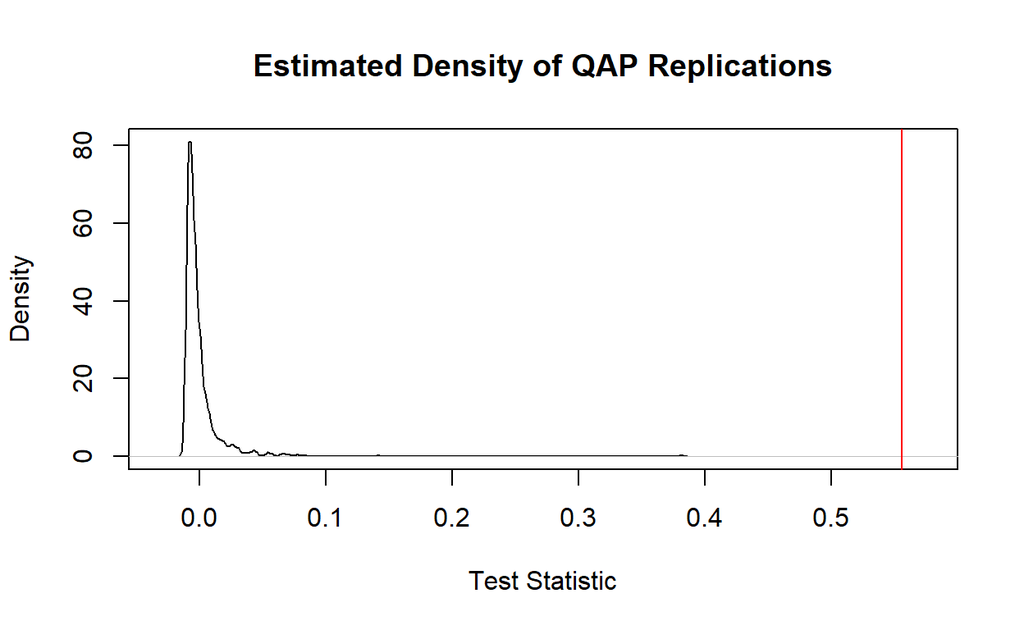

The correlation between trade 1964 and 2014 is much lower (0.56). It indicates the trade relationship does change a lot during the 50 years. But still, the score is significantly higher than random. (p>0.001) The trade network in 2014 can be predicted a lot by network in 1964.